# Business Statistics: E-news Express

## Define Problem Statement and Objectives

Problem Statement: E-news Express, an online news portal, would like to expand its business by acquiring new subscribers. The executives at E-news believe that there has been a decline in new monthly subscribers compared to last year. They believe that the main reason for the decline is that the current website is not designed well enough to keep customer's engaged.

Objective:

The design team of the company has created a new landing page in order to keep customers more engaged which will hopefully encourge them to subscribe. In order to test the effectiveness of the new landing page in gathering new subscribers, the Data Science team conducted an experiment by randomly selecting 100 users and dividing them equally into two groups. The existing landing page was served to the first group(control group) and the new landing page to the second group(treatment group). We have been asked to explore the data and perfom a statistical analysis(signifcance level of 5%) to determine the effectivness of the new landing page in gathering new subscribers for the news portal by answering the following questions:

```
1. Do the users spend more time on the new landing page than on the existing landing page?

2. Is the conversion rate (the proportion of users who visit the landing page and get converted) for the new page
greater than the conversion rate for the old page?

3. Does the converted status depend on the preferred language?

4. is the time spent on the new page the same for the different language users?
```

## Import all the necessary libraries

```python
import pandas as pd #library used for data manipulation and analysis
import numpy as np # library used for working with arrays.
import matplotlib.pyplot as plt # library for plots and visualisations
import seaborn as sns # library for visualisations
%matplotlib inline

import scipy.stats as stats
```

## Reading the Data into a DataFrame

```python
df=pd.read_csv('abtest.csv')
```

## Explore the dataset and extract insights using Exploratory Data Analysis

- Data Overview
  - Viewing the first and last few rows of the dataset
  - Checking the shape of the dataset
  - Getting the statistical summary for the variables
- Check for missing values
- Check for duplicates

```python
df.head() #first 5 rows
```

|  | user_id | group | landing_page | time_spent_on_the_page | converted | language_preferred |
| --- | --- | --- | --- | --- | --- | --- |
| 0 | 546592 | control | old | 3.48 | no | Spanish |
| 1 | 546468 | treatment | new | 7.13 | yes | English |
| 2 | 546462 | treatment | new | 4.40 | no | Spanish |
| 3 | 546567 | control | old | 3.02 | no | French |
| 4 | 546459 | treatment | new | 4.75 | yes | Spanish |

The dataset contains the user id, group, landing page, time spent on the page, converted status, and language preferred in each row.

```python
df.tail() #last 5 rows
```

|  | user_id | group | landing_page | time_spent_on_the_page | converted | language_preferred |
| --- | --- | --- | --- | --- | --- | --- |
| 95 | 546446 | treatment | new | 5.15 | no | Spanish |
| 96 | 546544 | control | old | 6.52 | yes | English |
| 97 | 546472 | treatment | new | 7.07 | yes | Spanish |
| 98 | 546481 | treatment | new | 6.20 | yes | Spanish |
| 99 | 546483 | treatment | new | 5.86 | yes | English |

```python
df.shape
```

```
(100, 6)
```

The data contains 100 rows and 6 columns

```python
df.describe()
```

|  | user_id | time_spent_on_the_page |
| --- | --- | --- |
| count | 100.000000 | 100.000000 |
| mean | 546517.000000 | 5.377800 |
| std | 52.295779 | 2.378166 |
| min | 546443.000000 | 0.190000 |
| 25% | 546467.750000 | 3.880000 |
| 50% | 546492.500000 | 5.415000 |
| 75% | 546567.250000 | 7.022500 |
| max | 546592.000000 | 10.710000 |

The mean time spent on the page is 5.38 minutes. The minimum is 0.19 minutes and the maximum is 10.71 minutes.

```python
df.info()
```

```
<class 'pandas.core.frame.DataFrame'>
RangeIndex: 100 entries, 0 to 99
Data columns (total 6 columns):
 #   Column                  Non-Null Count  Dtype
---  ------                  --------------  -----
 0   user_id                 100 non-null    int64
 1   group                   100 non-null    object
 2   landing_page            100 non-null    object
 3   time_spent_on_the_page  100 non-null    float64
 4   converted               100 non-null    object
 5   language_preferred      100 non-null    object
dtypes: float64(1), int64(1), object(4)
memory usage: 4.8+ KB
```

The user id and time spent on the page are numerical. While group, landing page, converted status, and language preferred are categorical.

```python
df.value_counts()
```

```
user_id  group      landing_page  time_spent_on_the_page  converted  language_preferred
546443   treatment  new           8.73                    no         English               1
546556   control    old           3.52                    yes        English               1
546566   control    old           8.35                    no         French                1
546565   control    old           8.02                    no         French                1
546564   control    old           0.91                    no         French                1
                                                                                          ..
546473   treatment  new           10.50                   yes        English               1
546472   treatment  new           7.07                    yes        Spanish               1
546471   treatment  new           7.81                    yes        French                1
546470   treatment  new           6.01                    yes        French                1
546592   control    old           3.48                    no         Spanish               1
Length: 100, dtype: int64
```

```python
df.language_preferred.value_counts()
```

```
Spanish    34
French     34
English    32
Name: language_preferred, dtype: int64
```

The sample is of 100 people. They are divided into two groups and two landing pages. In addition, 34 each preferred Spanish and French language, while 32 preferred English language.

```python
df.isnull().sum()
```

```
user_id                   0
group                     0
landing_page              0
time_spent_on_the_page    0
converted                 0
language_preferred        0
dtype: int64
```

```python
df.isna().sum()
```

```
user_id                   0
group                     0
landing_page              0
time_spent_on_the_page    0
converted                 0
language_preferred        0
dtype: int64
```

There are 0 missing values.

```python
df.duplicated().sum
```

```
<bound method NDFrame._add_numeric_operations.<locals>.sum of 0     False
1     False
2     False
3     False
4     False
      ...
95    False
96    False
97    False
98    False
99    False
Length: 100, dtype: bool>
```

```python
df['user_id'].nunique()
```

```
100
```

There are 0 duplicates.

```python
df['group'].value_counts()
```

```
control      50
treatment    50
Name: group, dtype: int64
```

The participants in the control and treatment groups were divided equally.

```python
df['landing_page'].value_counts()
```

```
old    50
new    50
Name: landing_page, dtype: int64
```

```python
df['time_spent_on_the_page'].mean()
```

```
5.377800000000002
```

The average time spent on the landing pages was 5.37 minutes

```python
df['converted'].value_counts()
```

```
yes    54
no     46
Name: converted, dtype: int64
```

Of the 100 users, 54 were converted to a subscriber.

### Univariate Analysis

#### Group

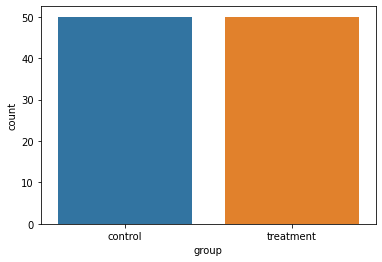

```python
sns.countplot(data=df, x="group")
plt.show()
```

```python
df['group'].value_counts()
```

```
control      50
treatment    50
Name: group, dtype: int64
```

50 users were part of the control group, and 50 were part of the treatment group.

#### Landing Page

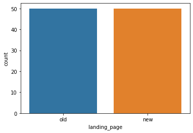

```python
sns.countplot(data=df, x="landing_page")
plt.show()
```

```python
df['landing_page'].value_counts()
```

```
old    50
new    50
Name: landing_page, dtype: int64
```

50 users visited the old landing page and 50 users visited the new landing page.

#### Time spent on the page

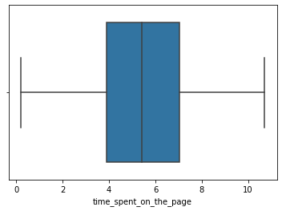

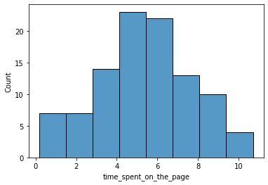

```python
sns.boxplot(data=df, x="time_spent_on_the_page")
plt.show()

sns.histplot(data=df, x='time_spent_on_the_page')
plt.show()
```

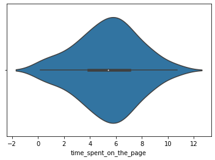

```python
sns.violinplot(data=df, x='time_spent_on_the_page');
```

```python
df['time_spent_on_the_page'].mean()
```

```
5.377800000000002
```

The average time spent on the old and new page was 5.38 minutes.

#### Converted

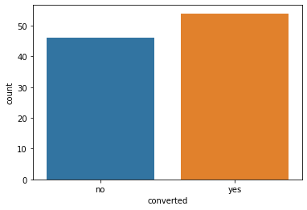

```python
sns.countplot(data=df, x="converted")
plt.show()
```

```python
df['converted'].value_counts()
```

```
yes    54
no     46
Name: converted, dtype: int64
```

Of the 100 users, 54 were converted and 46 were not converted.

#### Language preferred

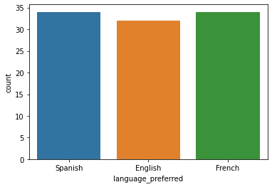

```python
sns.countplot(data=df, x="language_preferred")
plt.show()
```

```python
df['language_preferred'].value_counts() #counts of language preferred
```

```
Spanish    34
French     34
English    32
Name: language_preferred, dtype: int64
```

Spanish and French were the most preferred language. English was the least preferred.

### Bivariate Analysis

#### User Id

```python
df['user_id'].nunique() #of unique user id's
```

```
100
```

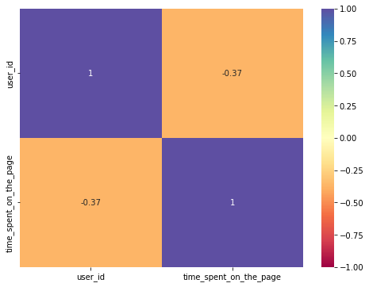

```python
plt.figure(figsize=(8,6))
sns.heatmap(df.corr(),annot=True, cmap='Spectral', vmin=-1, vmax=1)
plt.show()
```

#### Group vs Landing Page

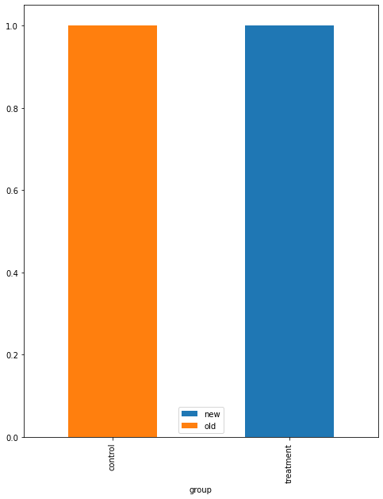

```python
pd.crosstab(df['group'],df['landing_page'],normalize='index').plot(kind='bar', figsize=(8,10), stacked=True)
plt.legend()
plt.show()
```

```python
group_landing_table = pd.crosstab(df['group'], df['landing_page'])
group_landing_table
```

| landing_page group | new | old |
| --- | --- | --- |
| control | 0 | 50 |
| treatment | 50 | 0 |

The control group visited the old landing page, whereas the treatment group visited the new landing page.

#### Group vs Time spent on the page

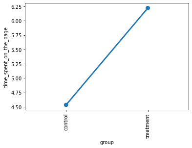

```python
sns.pointplot(x="group", y="time_spent_on_the_page", data=df, ci=None)
plt.xticks(rotation=90);
```

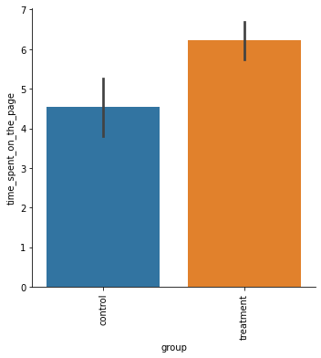

```python
plt.figure(figsize=(20,6))
sns.catplot(data=df,x= 'group', y='time_spent_on_the_page', kind='bar');
plt.xticks(rotation=90);
```

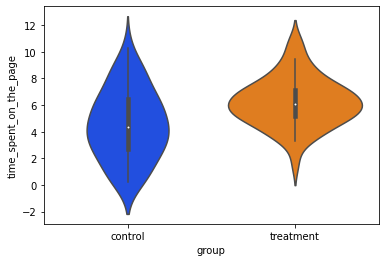

```python
sns.violinplot(data=df, x='group', y='time_spent_on_the_page', palette="bright");
```

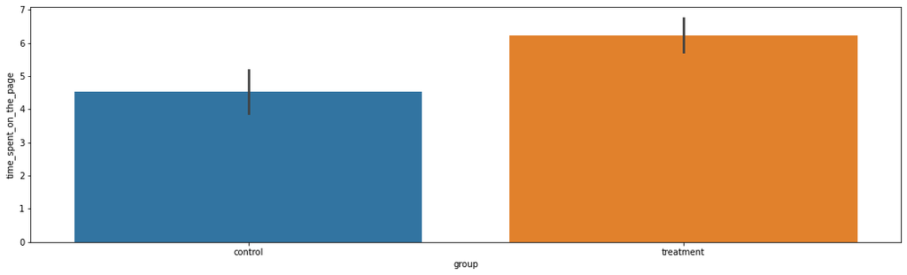

```python
plt.figure(figsize=(18,5))
sns.barplot(data=df, x='group', y='time_spent_on_the_page');
```

```python
df_control=df[df['group']=='control']
df_control.groupby(['group'])['time_spent_on_the_page'].mean()
```

```
group
control    4.5324
Name: time_spent_on_the_page, dtype: float64
```

```python
df_treatment=df[df['group']=='treatment']
df_treatment.groupby(['group'])['time_spent_on_the_page'].mean()
```

```
group
treatment    6.2232
Name: time_spent_on_the_page, dtype: float64
```

On average, the treatment group spent 6.22 minutes on the new landing page and the control group spent 4.53 minutes on the old landing page.

#### Group vs Converted

[figure not shown]

```python
sns.lineplot(data=df, x='group', y='converted');
```

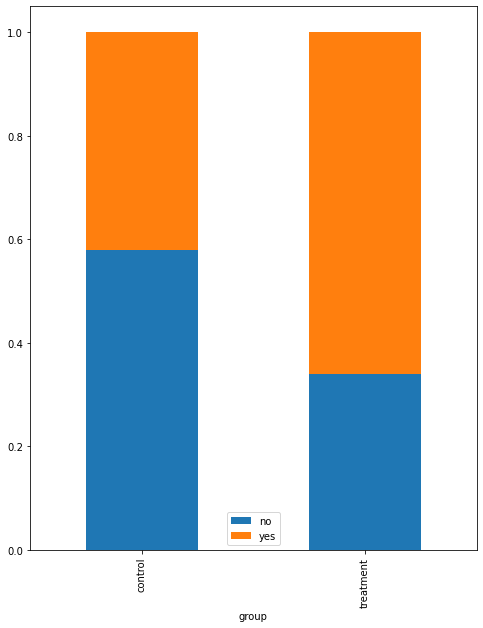

```python
pd.crosstab(df['group'],df['converted'],normalize='index').plot(kind='bar', figsize=(8,10), stacked=True)
plt.legend()
plt.show()
```

```python
group_converted_table = pd.crosstab(df['group'], df['converted'])#number of converted per group
group_converted_table
```

| converted group | no | yes |
| --- | --- | --- |
| control | 29 | 21 |
| treatment | 17 | 33 |

The treatment group had a higher converted rate than the control group.

#### Group vs Language preferred

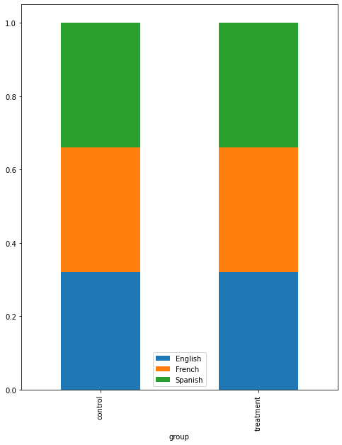

```python
pd.crosstab(df['group'],df['language_preferred'],normalize='index').plot(kind='bar', figsize=(8,10), stacked=True)
plt.legend()
plt.show()
```

```python
group_language_table = pd.crosstab(df['group'], df['language_preferred'])
group_language_table
```

| language_preferred group | English | French | Spanish |
| --- | --- | --- | --- |
| control | 16 | 17 | 17 |
| treatment | 16 | 17 | 17 |

Language preferred for the control and treatment groups was evenly distributed amongst all three languages.

#### Landing page vs Time spent on the page

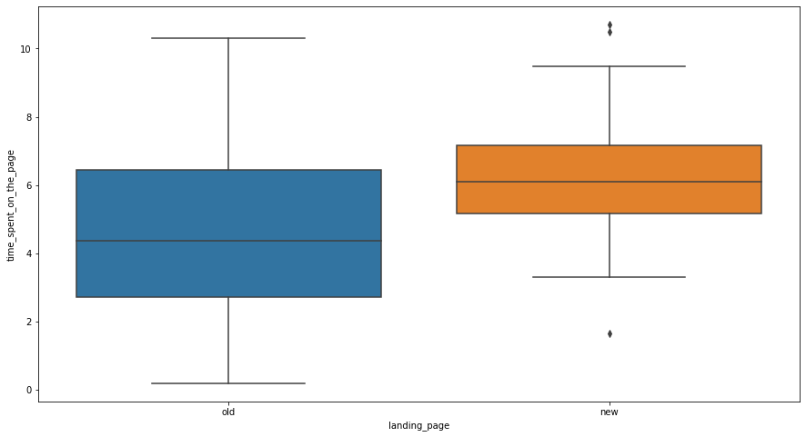

```python
plt.figure(figsize=(15,8))
sns.boxplot(data=df,x='landing_page',y='time_spent_on_the_page')
plt.show()
```

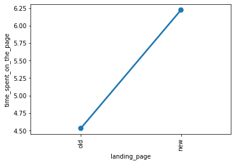

```python
sns.pointplot(x="landing_page", y="time_spent_on_the_page", data=df, ci=None)
plt.xticks(rotation=90);
```

```python
df_old=df[df['landing_page']=='old']
df_old.groupby(['landing_page'])['time_spent_on_the_page'].mean()
```

```
landing_page
old    4.5324
Name: time_spent_on_the_page, dtype: float64
```

```python
df_new=df[df['landing_page']=='new']
df_new.groupby(['landing_page'])['time_spent_on_the_page'].mean()
```

```
landing_page
new    6.2232
Name: time_spent_on_the_page, dtype: float64
```

Average time spent on the old landing page was 4.53 minutes. Average time spent on the new landing page was 6.22 minutes.

#### Landing page vs Converted

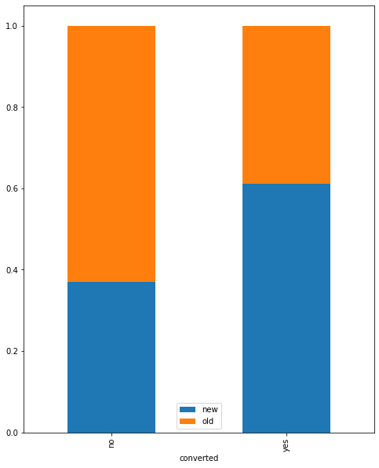

```python
pd.crosstab(df['converted'],df['landing_page'],normalize='index').plot(kind='bar', figsize=(8,10), stacked=True)
plt.legend()
plt.show()
```

```python
converted_landing_table = pd.crosstab(df['converted'], df['landing_page'])
converted_landing_table
```

| landing_page converted | new | old |
| --- | --- | --- |
| no | 17 | 29 |
| yes | 33 | 21 |

21 users were converted to subscribers from the old landing page. Whereas, 33 were converted to subscribers from the new landing page.

#### Landing page vs language preferred

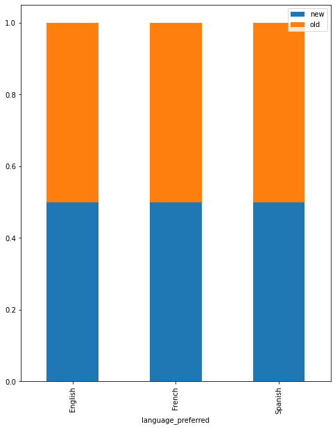

```python
pd.crosstab(df['language_preferred'],df['landing_page'],normalize='index').plot(kind='bar', figsize=(8,10), stacked=True)
plt.legend()
plt.show()
```

```python
landing_language_table = pd.crosstab(df['landing_page'], df['language_preferred'])
landing_language_table
```

| language_preferred landing_page | English | French | Spanish |
| --- | --- | --- | --- |
| new | 16 | 17 | 17 |
| old | 16 | 17 | 17 |

#### Time spent on page vs Converted

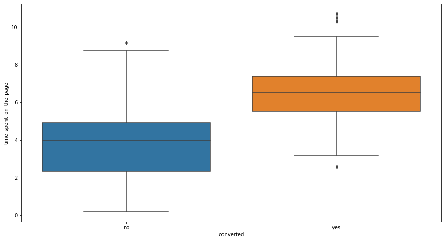

```python
plt.figure(figsize=(15,8))
sns.boxplot(data=df,x='converted',y='time_spent_on_the_page')
plt.show()
```

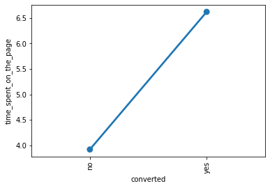

```python
sns.pointplot(x="converted", y="time_spent_on_the_page", data=df, ci=None)
plt.xticks(rotation=90);
```

```python
df_no=df[df['converted']=='no'] #time on page no conversion
df_no.groupby(['converted'])['time_spent_on_the_page'].mean()
```

```
converted
no    3.91587
Name: time_spent_on_the_page, dtype: float64
```

```python
df_yes=df[df['converted']=='yes'] #time spent on page with conversion
df_yes.groupby(['converted'])['time_spent_on_the_page'].mean()
```

```
converted
yes    6.623148
Name: time_spent_on_the_page, dtype: float64
```

Average time spent for users who did not convert to the new page was 3.92 minutes. Average time spent for users who did convert to the new page was 6.62 minutes.

#### Time spent on page vs Language preferred

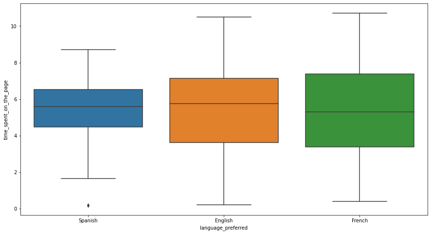

```python
plt.figure(figsize=(15,8))
sns.boxplot(data=df,x='language_preferred',y='time_spent_on_the_page')
plt.show()
```

```python
df_new=df[df['landing_page']=='new']
#df.head()
```

```python
#Average time spent on the new page in minutes.
df_new.groupby(['language_preferred'])['time_spent_on_the_page'].mean()
```

```
language_preferred
English    6.663750
French     6.196471
Spanish    5.835294
Name: time_spent_on_the_page, dtype: float64
```

```python
df_old=df[df['landing_page']=='old']
```

```python
#Average time spent on the old page in minutes.
df_old.groupby(['language_preferred'])['time_spent_on_the_page'].mean()
```

```
language_preferred
English    4.454375
French     4.310000
Spanish    4.828235
Name: time_spent_on_the_page, dtype: float64
```

Average time spent on the new page has increased for all languages from time spent on the old page.

#### Converted vs Language preferred

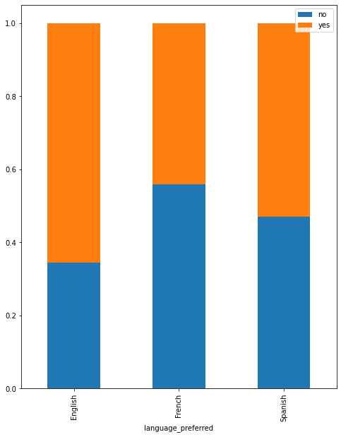

```python
pd.crosstab(df['language_preferred'],df['converted'],normalize='index').plot(kind='bar', figsize=(8,10), stacked=True)
plt.legend()
plt.show()
```

```python
#calculate converted status based on language
converted_language_table = pd.crosstab(df['converted'], df['language_preferred'])
converted_language_table
```

| language_preferred converted | English | French | Spanish |
| --- | --- | --- | --- |
| no | 11 | 19 | 16 |
| yes | 21 | 15 | 18 |

Users who's preferred language is English had the highest conversion to a subscriber of the new portal.  
User's who's preferred language is French had the least conversions to a subscriber of the new portal.

## Determine if users spend more time on the new landing page than the existing landing page?

### Perform Visual Analysis

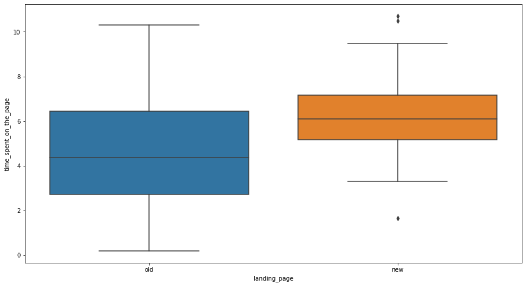

```python
plt.figure(figsize=(15,8))
sns.boxplot(data=df,x='landing_page',y='time_spent_on_the_page')
plt.show()
```

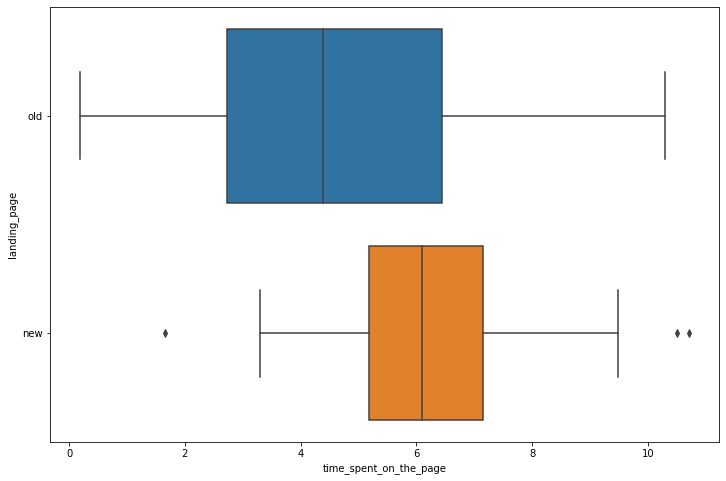

```python
plt.figure(figsize=(12,8))
sns.boxplot(data=df,x='time_spent_on_the_page',y='landing_page')
plt.show()
```

The means of the time spent on the old and new landing pages appear to differ.  
Users appear to spend more time on the new landing page.

### Step 1: Define the null and alternate hypotheses

Ho: μ1=μ2. Users time spent on the new landing page is equal to the time spent on the old landing page. #null hypothesis

Ha: μ1>μ2. Users time spent on the new landing page is greater than time spent on the old landing page. #alternative hypothesis

### Step 2: Select Appropriate test

2 sample means independent t-test

### Step 3: Decide the significance level

We will use a significance level of α = 0.05.

### Step 4: Collect and prepare data

```python
new_time_on_page = df[df['landing_page'] =='new']['time_spent_on_the_page']

old_time_on_page = df[df['landing_page'] =='old']['time_spent_on_the_page']
```

```python
print('The standard deviation of time spent on the new page is:', round(new_time_on_page.std(),2))
print('The standard deviation of time spent on the old page is:', round(old_time_on_page.std(),2))
```

```
The standard deviation of time spent on the new page is: 1.82
The standard deviation of time spent on the old page is: 2.58
```

### Step 5: Calculate the p-value

```python
from scipy.stats import ttest_ind


test_stat, p_value =ttest_ind(new_time_on_page, old_time_on_page, equal_var=False, alternative ='two-sided')

print('The p-value is', p_value)
```

```
The p-value is 0.0002784762450333098
```

### Step 6: Compare the p-value with $\alpha$

```python
if p_value < 0.05:
    print(f'As the p-value {p_value} is less than the level of significance, we reject the null hypothesis.')
else:
    print(f'As the p-value {p_value} is greater than the level of significance, we fail to reject the null hypothesis.')
```

```
As the p-value 0.0002784762450333098 is less than the level of significance, we reject the null hypothesis.
```

### Step 7: Draw inference

At 5% significance level, we reject the null hypothesis. We have enough statistical evidence to say that users spend more time on the new landing page than they do on the old landing page.

**A similar approach can be followed to answer the other questions.**

## Does the conversion rate for the new page differ than the conversion rate for the old page?

#### Perform Visual Analysis

```python
df['converted'].value_counts() #conversion totals
```

```
yes    54
no     46
Name: converted, dtype: int64
```

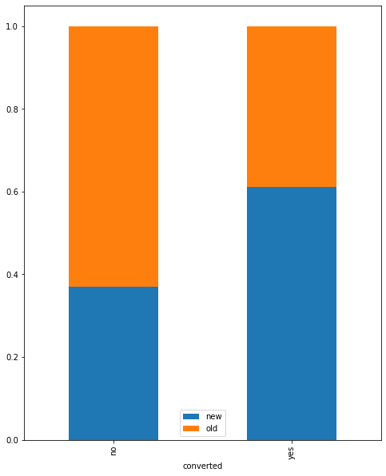

```python
pd.crosstab(df['converted'],df['landing_page'],normalize='index').plot(kind='bar', figsize=(8,10), stacked=True)
plt.legend()
plt.show()
```

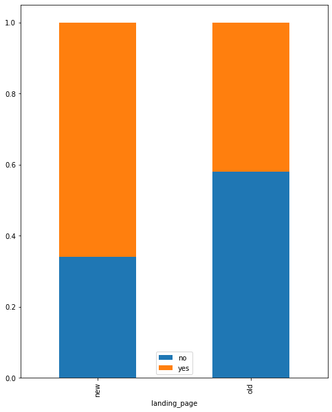

```python
pd.crosstab(df['landing_page'],df['converted'],normalize='index').plot(kind='bar', figsize=(8,10), stacked=True)
plt.legend()
plt.show()
```

```python
contingency_table = pd.crosstab(df['landing_page'], df['converted'])
contingency_table
```

| converted landing_page | no | yes |
| --- | --- | --- |
| new | 17 | 33 |
| old | 29 | 21 |

Users of the new page get converted to a subscriber of the news portal at a higher rate than users of the old page.

```python
import numpy as np
import pandas as pd

from statsmodels.stats.proportion import proportions_ztest
```

#### Step 1: Define the null and alternate hypotheses

Ho: p1<=p2. The new page conversion rate is less than or equal to the old page conversion rate.

Ha: p1>p2. The new page conversion rate is greater than the old page conversion rate.

#### Step 2: Select Appropriate test

Two Proportion Z-test

#### Step 3: Decide the significance level

We will use a significance level of α = 0.05

#### Step 4: Collect and prepare data

```python
new_page_converted = df[df['group']=='treatment'].converted.value_counts()['yes']

old_page_converted = df[df['group']=='control'].converted.value_counts()['yes']

print('The number of treatment and control users converted to the new page are {0} and {1} respectively'.format(new_page_converted, old_page_converted))

#number of people n the treatment group
n_treatment= df.group.value_counts()['treatment']

#number of people in the control group
n_control=df.group.value_counts()['control']


print('The total number of people who visited the old and new page are {0} and {1} respectively'.format(n_control, n_treatment))
```

```
The number of treatment and control users converted to the new page are 33 and 21 respectively
The total number of people who visited the old and new page are 50 and 50 respectively
```

#### Step 5: Calculate the p-value

```python
stat, pval =proportions_ztest([new_page_converted, old_page_converted], [n_control, n_treatment], alternative='two-sided')

print('The p-value is '+str(pval))
```

```
The p-value is 0.016052616408112556
```

#### Step 6: Compare the p-value with 𝛼

```python
if p_value < 0.05:
    print(f'As the p-value {pval} is less than the level of significance, we reject the null hypothesis.')
else:
    print(f'As the p-value {pval} is greater than the level of significance, we fail to reject the null hypothesis.')
```

```
As the p-value 0.016052616408112556 is less than the level of significance, we reject the null hypothesis.
```

#### Step 7: Draw inference

Since the p-value is less than the level of significance(5%), we reject the null hypothesis. Hence we have enough statistical evidence to say that the conversion rate of users visiting the new page is greater than the conversion rate of users visiting the old page.

## Are the conversion rate and preferred language independent of each other or related?

#### Perform Visual Analysis

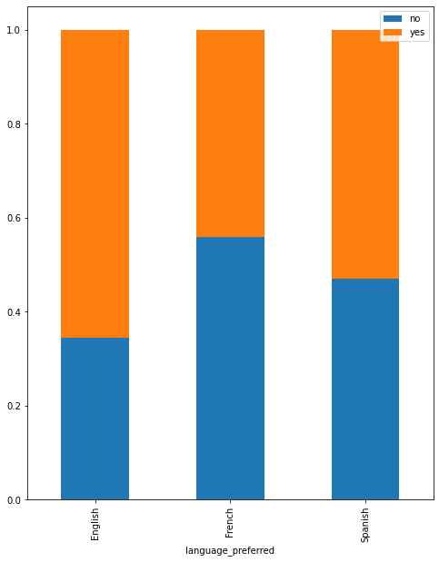

```python
pd.crosstab(df['language_preferred'],df['converted'],normalize='index').plot(kind='bar', figsize=(8,10), stacked=True)
plt.legend()
plt.show()
```

```python
contingency_table = pd.crosstab(df['language_preferred'], df['converted'])
contingency_table
```

| converted language_preferred | no | yes |
| --- | --- | --- |
| English | 11 | 21 |
| French | 19 | 15 |
| Spanish | 16 | 18 |

Users with language preferred of English appear to have the highest converted rate (21). Spanish language is second (18), and French has the least (15).

```python
#import necessary libraries
import numpy as np
import pandas as pd
import matplotlib.pyplot as plt
import seaborn as sns
from scipy.stats import chi2_contingency
```

#### Step 1: Define the null and alternate hypotheses

Ho: The conversion rate is independent of preferred language.

Ha: The conversion rate is NOT independent of preferred language.

#### Step 2: Select Appropriate test

Chi Square Test of Independence

#### Step 3: Decide the significance level

We will use a significance level of α = 0.05

#### Step 4: Collect and prepare data

```python
contingency_table = pd.crosstab(df['language_preferred'], df['converted'])
contingency_table
```

| converted language_preferred | no | yes |
| --- | --- | --- |
| English | 11 | 21 |
| French | 19 | 15 |
| Spanish | 16 | 18 |

#### Step 5: Calculate the p-value

```python
#code to calculate p-value
chi2, pvalue1, dof, exp_freq = chi2_contingency(contingency_table)
print('The p-value is', pvalue1)
```

```
The p-value is 0.2129888748754345
```

#### Step 6: Compare the p-value with 𝛼

```python
if pvalue1 < 0.05:
    print(f'As the p-value {pvalue1} is less than the level of significance, we reject the null hypothesis.')
else:
    print(f'As the p-value {pvalue1} is greater than the level of significance, we fail to reject the null hypothesis.')
```

```
As the p-value 0.2129888748754345 is greater than the level of significance, we fail to reject the null hypothesis.
```

#### Step 7: Draw inference

Since the p-value is greater than the level of significance(5%), we do not reject the null hypothesis. Hence, we do not have enough statistical evidence to say that the conversion rate is NOT independent of preferred language.

## Does the time spent on the new page differ across the different language users?

#### Perform Visual Analysis

```python
df.describe() #statistical summary of time spent on the page
```

|  | user_id | time_spent_on_the_page |
| --- | --- | --- |
| count | 100.000000 | 100.000000 |
| mean | 546517.000000 | 5.377800 |
| std | 52.295779 | 2.378166 |
| min | 546443.000000 | 0.190000 |
| 25% | 546467.750000 | 3.880000 |
| 50% | 546492.500000 | 5.415000 |
| 75% | 546567.250000 | 7.022500 |
| max | 546592.000000 | 10.710000 |

```python
df.language_preferred.value_counts()
```

```
Spanish    34
French     34
English    32
Name: language_preferred, dtype: int64
```

```python
df_new_page=df[df['landing_page']=='new']
df.head()
```

|  | user_id | group | landing_page | time_spent_on_the_page | converted | language_preferred |
| --- | --- | --- | --- | --- | --- | --- |
| 0 | 546592 | control | old | 3.48 | no | Spanish |
| 1 | 546468 | treatment | new | 7.13 | yes | English |
| 2 | 546462 | treatment | new | 4.40 | no | Spanish |
| 3 | 546567 | control | old | 3.02 | no | French |
| 4 | 546459 | treatment | new | 4.75 | yes | Spanish |

```python
df_new_page.groupby(['language_preferred'])['time_spent_on_the_page'].mean()
```

```
language_preferred
English    6.663750
French     6.196471
Spanish    5.835294
Name: time_spent_on_the_page, dtype: float64
```

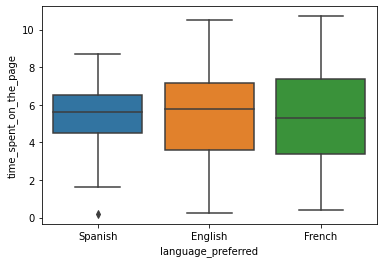

```python
sns.boxplot(x='language_preferred', y='time_spent_on_the_page', data=df)
plt.show()
```

The distribution of the time spent on the page appears to be similar for all languages.

English appears to have the highest average time spent on the page(6.66 minutes). French(6.19 minutes), and Spanish(5.84 minutes).

#### Step 1: Define the null and alternate hypotheses

Ha: At least one of the languages calculated time spent on the new page is not the same from the other different language users.

#### Step 2: Select Appropriate test

One-way ANOVA test

```python
#Shapiro-Wilk's Test
from scipy import stats

w, p_value2=stats.shapiro(df['time_spent_on_the_page'])
print('The p-value is', p_value2)
```

```
The p-value is 0.5643684267997742
```

Since the p-value of the test is very large, we fail to reject the null hypothesis that the response follows the normal distribution.

```python
#Levene's Test
from scipy.stats import levene
statistic, p_value2 = levene(df[df['language_preferred']=='English']['time_spent_on_the_page'],
                            df[df['language_preferred']=='French']['time_spent_on_the_page'],
                            df[df['language_preferred']=='Spanish']['time_spent_on_the_page'])
print('The p-value is', p_value2)
```

```
The p-value is 0.06515086840327314
```

Since the p-value is greater than the significance level of 0.05, we fail to reject the null hypothesis fo homogeneity of variances.

The populations are normally distributed. The population variances are equal.

#### Step 3: Decide the significance level

We will use a significance level of α = 0.05

#### Step 4: Collect and prepare data

```python
contingency_table = pd.crosstab(df['landing_page'], df['language_preferred'])
contingency_table
```

| language_preferred landing_page | English | French | Spanish |
| --- | --- | --- | --- |
| new | 16 | 17 | 17 |
| old | 16 | 17 | 17 |

```python
#English time spent on the new page
English_time_spent_new=df[df['language_preferred']=='English']['time_spent_on_the_page']
#French time spent on the new page
French_time_spent_new=df[df['language_preferred']=='French']['time_spent_on_the_page']

#Spanish time spent on the new page
Spanish_time_spent_new=df[df['language_preferred']=='Spanish']['time_spent_on_the_page']
```

#### Step 5: Calculate the p-value

```python
from scipy.stats import f_oneway

test_stat, p_value2=f_oneway(English_time_spent_new, French_time_spent_new, Spanish_time_spent_new)
print('the p-value is', p_value2)
```

```
the p-value is 0.8665610536012648
```

#### Step 6: Compare the p-value with 𝛼

```python
if p_value2 < 0.05:
    print(f'As the p-value {p_value2} is less than the level of significance, we reject the null hypothesis.')
else:
    print(f'As the p-value {p_value2} is greater than the level of significance, we fail to reject the null hypothesis.')
```

```
As the p-value 0.8665610536012648 is greater than the level of significance, we fail to reject the null hypothesis.
```

## Conclusion and Business Recommendations

Conclusion:

The new landing page is effective at converting more users to subscribers.

Average time spent on the new page has increased for all languages from time spent on the old page.

Users who's preferred language is English had the highest conversion to a subscriber of the new portal. Users who's preferred language is French had the least conversions to a subscriber of the new portal.

We do not have enough statistical evidence to say that the conversion rate is NOT independent of preferred language.

We have enough statistical evidence to say that the conversion rate of users visiting the new page is greater than the conversion rate of users visiting the old page.

We have enough statistical evidence to say that users spend more time on the new landing page than they do on the old landing page.

Business Recommendations:

The company should continue to use the new landing page since the evidence supports that it is effective at increasing the amount of time spent on the landing page resulting in more users subscribing to the portal.

Since users with preferred language of English had the highest conversion rate, the company should focus on that group to increase subscribers. In addition, more research is needed to determine how to increase subscribers who's preferred language is Spanish or French.